# Ptychodera Cisreg Development: Comparative Analysis Figures

Alberto Perez-Posada

09/05/2024

## About

We will assess the transcriptomic similarity between three deuterostome species using a common set of orthologues.

## Load libraries

```r
library(DESeq2)
library(limma)
library(ComplexHeatmap)
library(circlize)
library(RColorBrewer)
require(colorspace)
```

## Load functions

```r
source("code/r_code/r_functions/sourcefolder.R")

sourceFolder(
  "code/r_code/r_functions",
  recursive = TRUE
  )

sourceFolder(
  "code/r_code/r_general",
  recursive = TRUE
  )
```

## Load data

We will load all the comparABle wrappers that we have generated in all the markdowns of this section.

```r
load("outputs/rda/deseq2.rda")
load("outputs/rda/bflo_reanalysis.rda")
load("outputs/rda/spur_reanalysis.rda")
ALGs <-
  read.delim2(
    file = "outputs/functional_annotation/ALG_genes/all_ALGs.tsv",
    header = TRUE
    )
```

We will parse and keep tidy all the dictionaries of IDs of species

```r
xloc_tcons <- read.table("data/refs/genome/xloc_tcons_longestIso.tsv",header=F,col.names=c("id","gene"))
bflo_loc <- read.delim2("outputs/comparative/reanalysis/bflo/dict_genomepaper/BFL_transctiptID2geneID.tsv",header = TRUE)
bf_bflo <- read.table("outputs/comparative/oma/dicts/BRAFL.dct", col.names = c("key","value"))
bflo_loc <- bflo_loc[bflo_loc$transcript_id %in% bf_bflo$key,]
bflo_loc$id <- translate_ids(x = bflo_loc$transcript_id,dict = bf_bflo)
spur_loc <- read.delim2("outputs/comparative/reanalysis/spur/dict_genomepaper/SPU_transctiptID2geneID.tsv",header = TRUE)
sp_strpu <- read.table("outputs/comparative/oma/dicts/STRPU.dct", col.names = c("key","value"))
spur_loc <- spur_loc[spur_loc$protein_ID %in% sp_strpu$key,]
spur_loc$id <- translate_ids(x = spur_loc$protein_ID,dict = sp_strpu)
```

We collate all the ID equivalences here:

```r
ALGs$id_pfla <- translate_ids(ALGs$PFL, dict = xloc_tcons[,c(2,1)])
ALGs$id_bflo <- translate_ids(ALGs$BFL, dict = bflo_loc[,c(2,3)])
ALGs$id_spur <- translate_ids(ALGs$SPU,dict = spur_loc[,c(3,4)])

rownames(ALGs) <- ALGs$id_pfla
```

We can use this as a translation layer between the data of the three species.

## Filtering the data

With this we keep the genes that are in the expression matrices of the three species.

```r
common_alg_genes <-
  ALGs$id_pfla %in% rownames(pfla_rna_dev) &
  ALGs$id_spur %in% rownames(spur_vsd) &
  ALGs$id_bflo %in% rownames(bflo_vsd)

deut_or <- ALGs[common_alg_genes,c(4:7)]
deut_or$or <-
  paste0("O_",formatC(1:nrow(deut_or), width = nchar( trunc( abs(nrow(deut_or)) ) ), format = "d", flag = "0"))
```

First we subset the data of Ptychodera

```r
a <- pfla_rna_dev[rownames(pfla_rna_dev) %in% deut_or$id_pfla, -17]
rownames(a) <- translate_ids(rownames(a), dict = deut_or[,c(2,5)])
colnames(a) <- paste("PF_",sub("X","",colnames(a)))
```

Then S. purpuratus

```r
spur_dds <- DESeqDataSetFromMatrix(countData = spur_vsd, colData = data.frame(condition = colnames(spur_vsd)),design = ~ condition)
spur_dds <- estimateSizeFactors(spur_dds)
spur_norm <- counts(spur_dds, normalized=TRUE)

b <- spur_norm[rownames(spur_norm) %in% deut_or$id_spur,]
rownames(b) <- translate_ids(rownames(b), dict = deut_or[,c(4,5)])
colnames(b) <- paste("SP_",colnames(b))
```

& Then B. floridae

```r
c <- RNA_bflo[rownames(RNA_bflo) %in% deut_or$id_bflo,-c(13,14)]
rownames(c) <- translate_ids(rownames(c), dict = deut_or[,c(3,5)])
colnames(c) <- paste("BF_",colnames(c))
```

The intersect and the filtering:

```r
f <- intersect(rownames(a),intersect(rownames(b),rownames(c)))
a <- a[f,]
b <- b[f,]
c <- c[f,]
```

The data is ready to use.

## Comparison

We will use comparABle’s implementation of the Jensen-Shannon Distance:

```r
# Quant norm
a <- qnorm(a)
b <- qnorm(b)
c <- qnorm(c)

# The correlations:
cors_ab <- rawcorsp(a_o = a, b_o = b)
cors_ac <- rawcorsp(a_o = a, b_o = c)
cors_bc <- rawcorsp(a_o = b, b_o = c)
```

Then the heatmaps:

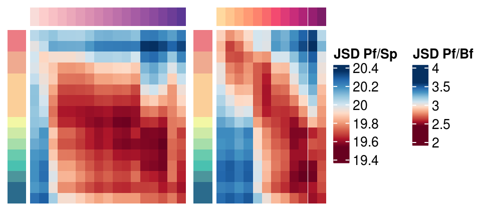

```r
h_ab <-
  Heatmap(
    name = "JSD Pf/Sp",
    cors_ab$js,
    cluster_rows = F, cluster_columns = F, show_row_names = F, show_column_names = F,
    col = brewer.pal(10,"RdBu"),
    left_annotation = devstages_ha_rows(),
    top_annotation = quick_ha(colnames(b),"Purple-Orange",rev = TRUE)
  )

h_ac <-
  Heatmap(
    name = "JSD Pf/Bf",
    cors_ac$js,
    cluster_rows = F, cluster_columns = F, show_row_names = F, show_column_names = F,
    col = brewer.pal(10,"RdBu"),
    left_annotation = devstages_ha_rows(),
    top_annotation = quick_ha(colnames(c),"SunsetDark",rev = TRUE)
  )
draw(h_ab+h_ac)
```

Since the JSD metric varies a lot between the species it does not make sense to normalise there. We can however use the metric of Spearman correlation as a proxy to see which stages are most similar between species.

```r
abc <- cbind(a,b,c)

abc_sp <- cor(abc, method = "sp")
```

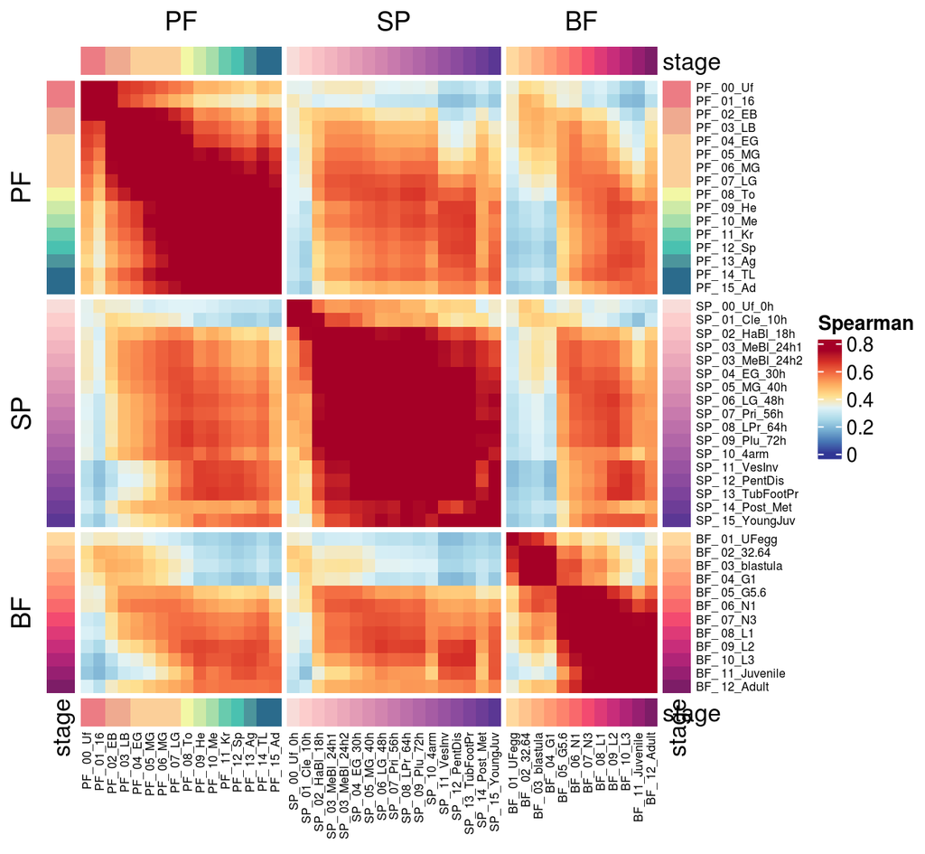

```r
ha =
  HeatmapAnnotation(
    stage = colnames(abc),
    col = list(stage =
                 setNames(
                   c(
                     dev_palette,
                     sequential_hcl(ncol(b),"Purple-Orange",rev = TRUE),
                     sequential_hcl(ncol(c),"SunsetDark",rev = TRUE)
                   ),
                   colnames(abc)
                 )),
    show_legend = FALSE, which = "column"
  )

ha_row =
  HeatmapAnnotation(
    stage = colnames(abc),
    col = list(stage =
                 setNames(
                   c(
                     dev_palette,
                     sequential_hcl(ncol(b),"Purple-Orange",rev = TRUE),
                     sequential_hcl(ncol(c),"SunsetDark",rev = TRUE)
                   ),
                   colnames(abc)
                 )),
    show_legend = FALSE, which = "row"
  )

h_abc_sp <-
  Heatmap(
    name = "Spearman",
    abc_sp,
    col = colorRamp2(seq(0,0.75, length = 10),rev(brewer.pal(10,"RdYlBu"))),
    cluster_rows = FALSE,
    cluster_columns = FALSE,
    row_split = factor(c(rep("PF",ncol(a)),rep("SP",ncol(b)),rep("BF",ncol(c))), levels = c("PF","SP","BF")),
    column_split = factor(c(rep("PF",ncol(a)),rep("SP",ncol(b)),rep("BF",ncol(c))), levels = c("PF","SP","BF")),
    row_names_gp = gpar(cex = .5),
    column_names_gp = gpar(cex = .5),
    top_annotation = ha,
    right_annotation = ha_row,
    bottom_annotation = ha,
    left_annotation = ha_row
  )


draw(h_abc_sp)
```

## Saving plots

```r
pdf("graphics/supp_08plus_AB.pdf",wi = 5, he = 2)
draw(h_ab+h_ac)
dev.off()
```

```r
pdf("graphics/supp_08plus_C.pdf",wi = 6.5, he = 6)
draw(h_abc_sp)
dev.off()
```